# Math250MidtermDos

```r
library(tidyverse)
library(readxl)
library(gt)

pizza_poll <- read_excel("pizza_poll.xlsx")
pizza_ratings <- read_excel("pizza_ratings.xlsx")
spotify <- read_csv("spotify_sample.csv")
scooby <- read_excel("scooby copy.xlsx")
```

## Problem 1

```r
rating <- c("Excellent" = 5, "Good" = 4, "Average" = 3, "Poor" = 2, "Never Again" = 1)
```

```r
pizza_poll <- pizza_poll %>%
  mutate(numeric_rating = rating[answer])

ratings_summary <- pizza_poll %>%
  group_by(place) %>%
  summarise(total_points = sum(numeric_rating * votes, na.rm = TRUE),
            total_votes = sum(votes, na.rm = TRUE))

ratings_summary <- ratings_summary %>%
  mutate(average_rating = round(total_points / total_votes,2))

top_pizza_shops <- ratings_summary %>%
  filter(total_votes >= 15) %>%
  arrange(desc(average_rating)) %>%
  slice_head(n = 10)

gt(top_pizza_shops)
```

| place | total_points | total_votes | average_rating |
| --- | --- | --- | --- |
| Tappo | 89 | 21 | 4.24 |
| Williamsburg Pizza | 161 | 39 | 4.13 |
| Rocky's | 115 | 29 | 3.97 |
| Fiore's | 487 | 123 | 3.96 |
| Spunto | 59 | 15 | 3.93 |
| Little Italy Pizza | 133 | 34 | 3.91 |
| Stella's Pizza | 58 | 15 | 3.87 |
| Gotham Pizza | 65 | 17 | 3.82 |
| Pizza Paradise | 65 | 17 | 3.82 |
| Rocco's Pizza Joint | 95 | 25 | 3.80 |

## Problem 2

Null (Ho): There is no difference in mean ratings across cost of pizza

Alternative (Ha): expensive pizza is more highly rated on average than cheap pizza

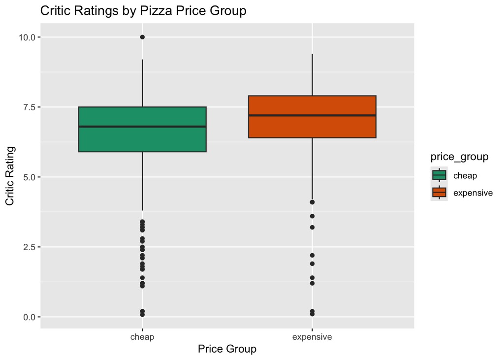

```r
pizza_ratings <- pizza_ratings %>%
  mutate(price_group = ifelse(price_level > 1, "expensive", "cheap"))

ggplot(pizza_ratings,
       aes(x = price_group,
           y = rating,
           fill = price_group)) +
  geom_boxplot() +
  scale_fill_brewer(palette = "Dark2") +
  labs(title = "Critic Ratings by Pizza Price Group",
       x = "Price Group",
       y = "Critic Rating")
```

```r
model_pizza <- t.test(rating ~ price_group,
                      data = pizza_ratings,
                      alternative = "greater")
model_pizza
```

```
    Welch Two Sample t-test

data:  rating by price_group
t = -4.3183, df = 432.84, p-value = 1
alternative hypothesis: true difference in means between group cheap and group expensive is greater than 0
95 percent confidence interval:
 -0.9809545        Inf
sample estimates:
    mean in group cheap mean in group expensive
               6.281217                6.991171
```

## Problem 3

```r
pizza_ratings <- pizza_ratings %>%
  rename(place = name)

combined <- inner_join(ratings_summary, pizza_ratings, by = "place")

gt(combined)
```

| place | total_points | total_votes | average_rating | city | price_level | rating | price_group |
| --- | --- | --- | --- | --- | --- | --- | --- |
| 5 Boroughs Pizza | 11 | 3 | 3.67 | New York | 1 | 3.4 | cheap |
| Artichoke Basille's Pizza | 41 | 10 | 4.10 | New York | 2 | 7.9 | expensive |
| Arturo's | 27 | 7 | 3.86 | New York | 2 | 7.9 | expensive |
| Bleecker Street Pizza | 29 | 7 | 4.14 | New York | 1 | 6.9 | cheap |
| Champion Pizza | 37 | 12 | 3.08 | New York | 1 | 8.1 | cheap |
| Girello | 40 | 10 | 4.00 | New York | 2 | 6.9 | expensive |
| Gotham Pizza | 65 | 17 | 3.82 | New York | 1 | 6.9 | cheap |
| Highline Pizza | 81 | 28 | 2.89 | New York | 1 | 1.7 | cheap |
| Joe's Pizza | 52 | 17 | 3.06 | New York | 1 | 8.5 | cheap |
| Kiss My Slice | 15 | 5 | 3.00 | New York | 0 | 7.1 | cheap |
| Little Italy Pizza | 133 | 34 | 3.91 | New York | 1 | 6.3 | cheap |
| NY Pizza Suprema | 263 | 75 | 3.51 | New York | 1 | 8.2 | cheap |
| Pizza Italia | 59 | 18 | 3.28 | New York | 1 | 4.2 | cheap |
| Previti Pizza | 75 | 26 | 2.88 | New York | 1 | 4.9 | cheap |
| Prince Street Pizza | 194 | 61 | 3.18 | New York | 1 | 8.6 | cheap |
| Rivoli Pizza | 120 | 34 | 3.53 | New York | 1 | 7.8 | cheap |
| Rocco's Pizza Joint | 95 | 25 | 3.80 | New York | 1 | 8.2 | cheap |
| Saluggi's | 144 | 38 | 3.79 | New York | 2 | 8.2 | expensive |
| Stella's Pizza | 58 | 15 | 3.87 | New York | 1 | 6.2 | cheap |
| Steve's Pizza | 19 | 6 | 3.17 | New York | 1 | 2.2 | cheap |
| Vinny Vincenz | 27 | 8 | 3.38 | New York | 1 | 8.4 | cheap |
| Williamsburg Pizza | 161 | 39 | 4.13 | Brooklyn | 1 | 8.6 | cheap |

The majority of the restaurants present on both are cheaper options, with decent reviews, and all are location in New York (With the exception of 1 in Brooklyn).

## Problem 4

Null: energy level and genre are independent.

Alternative: they’re not independent.

[figure not shown]

```r
ggplot(spotify,
       aes(x = genre,
           y = energy)) +
  geom_boxplot() +
  labs(title = "Song Energy Levels by Genre",
       x = "Song Energy",
       y = "Song Genre")
```

```r
spotify_anova <- aov(energy ~ genre, data = spotify)

summary(spotify_anova)
```

```
             Df Sum Sq Mean Sq F value   Pr(>F)
genre         5 0.6834 0.13668   5.902 6.88e-05 ***
Residuals   114 2.6399 0.02316
---
Signif. codes:  0 '***' 0.001 '**' 0.01 '*' 0.05 '.' 0.1 ' ' 1
```

With a p-value this small, you can pretty much guarantee that genre and energy level are not independent of each other, and that genre likely has a statistically significant effect on energy level.

## Problem 5

null: `energy` is independent of `tempo`

alt: `energy` is not independent of `tempo`

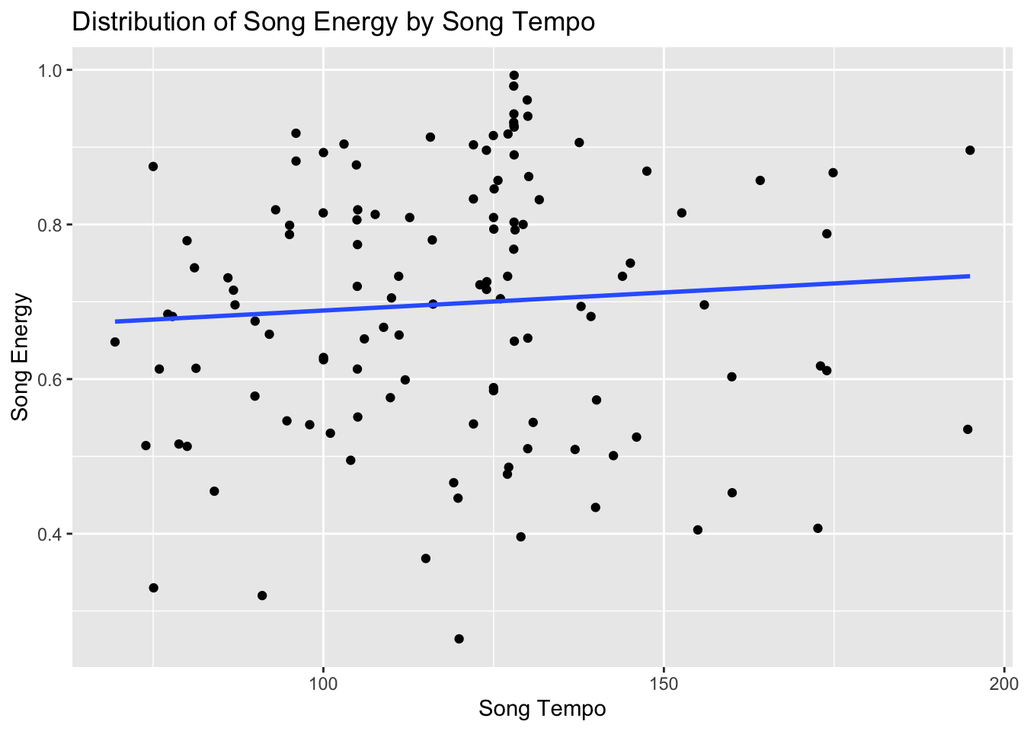

```r
ggplot(spotify,
       aes(x = tempo,
           y = energy)) +
  geom_point() +
  geom_smooth(method = "lm",
              se = FALSE) +
  labs(title = "Distribution of Song Energy by Song Tempo",
       x = "Song Tempo",
       y = "Song Energy")
```

```r
model2 <- lm(energy ~ tempo,
             data = spotify)

summary(model2)
```

```
Call:
lm(formula = energy ~ tempo, data = spotify)

Residuals:
     Min       1Q   Median       3Q      Max
-0.43401 -0.12158  0.01474  0.12976  0.29121

Coefficients:
             Estimate Std. Error t value Pr(>|t|)
(Intercept) 0.6419524  0.0714988   8.979 5.18e-15 ***
tempo       0.0004674  0.0005875   0.796    0.428
---
Signif. codes:  0 '***' 0.001 '**' 0.01 '*' 0.05 '.' 0.1 ' ' 1

Residual standard error: 0.1674 on 118 degrees of freedom
Multiple R-squared:  0.005336,  Adjusted R-squared:  -0.003093
F-statistic: 0.633 on 1 and 118 DF,  p-value: 0.4278
```

## Problem 6

```r
scooby_unmask <- scooby %>%
  select(title, imdb, starts_with("unmask_")) %>%
  pivot_longer(cols = starts_with("unmask_"),
               names_to = "unmasker",
               values_to = "did_unmask") %>%
  filter(did_unmask == TRUE) %>%
  mutate( unmasker = str_remove(unmasker, "unmask_"),
    unmasker = str_replace(unmasker, "daphnie", "daphne"),
    unmasker = str_to_title(unmasker)) %>%
  select(title, imdb, unmasker)

glimpse(scooby_unmask)
```

```
Rows: 261
Columns: 3
$ title    <chr> "What a Night for a Knight", "A Clue for Scooby Doo", "Hassle…
$ imdb     <dbl> 8.1, 8.1, 8.0, 7.8, 7.5, 8.4, 7.6, 8.2, 8.4, 8.1, 8.4, 8.3, 7…
$ unmasker <chr> "Scooby", "Fred", "Fred", "Fred", "Scooby", "Fred", "Shaggy",…
```

```r
scooby_unmask %>%
  count(unmasker, name = "unmask_count") %>%
  arrange(desc(unmask_count)) %>%
  gt()
```

| unmasker | unmask_count |
| --- | --- |
| Fred | 90 |
| Velma | 75 |
| Other | 34 |
| Daphne | 30 |
| Scooby | 21 |
| Shaggy | 11 |

## Problem 7

```r
scooby_sm <- scooby %>%
  filter(format == "TV Series")

top_motives <- scooby_sm %>%
  count(motive, sort = TRUE) %>%
  slice_head(n = 3) %>%
  pull(motive)

top_terrains <- scooby_sm %>%
  count(setting_terrain, sort = TRUE) %>%
  slice_head(n = 2) %>%
  pull(setting_terrain)

scooby_sm <- scooby_sm %>%
  filter(motive %in% top_motives,
         setting_terrain %in% top_terrains) %>%
  select(title, motive, setting_terrain)

glimpse(scooby_sm)
```

```
Rows: 185
Columns: 3
$ title           <chr> "What a Night for a Knight", "Scooby-Doo and a Mummy, …
$ motive          <chr> "Theft", "Theft", "Competition", "Theft", "Theft", "Tr…
$ setting_terrain <chr> "Urban", "Urban", "Rural", "Urban", "Rural", "Rural", …
```

## Problem 8

Null: No association between motive and setting terrain

Alt: There is an association

```r
table_sm <- table(scooby_sm$motive, scooby_sm$setting_terrain)

chisq_test <- chisq.test(table_sm)

chisq_test
```

```
    Pearson's Chi-squared test

data:  table_sm
X-squared = 22.784, df = 2, p-value = 1.129e-05
```

p value is tiny here, so we reject Ho and conclude that motive and terrain are associated in some capacity.